# 0330作業

統學

2021/3/29

```r
library(tidyverse)
```

一開始利用$LCG (Linear\ congruential\ generator)$製造自$Uniform(0,1)$抽樣的樣本。  
圖左邊為以LCG製造的$Uniform(0,1)$樣本所畫的直方圖及以該樣本所估計的Density Plot，與右圖$runif()$相比起來十分相似，從盒狀圖來看，也可看出兩組資料十分相近。

```r
# 此為LCG生成所用之演算法
lcg <- function(a,c,m,run.length,seed) {
  x <- rep(0,run.length)
  x[1] <- seed
  for (i in 1:(run.length-1)) {
    x[i+1] <- (a*x[i] + c) %% m
  }
  U <- x/m
  return(list(x=x,U=U))
}
```

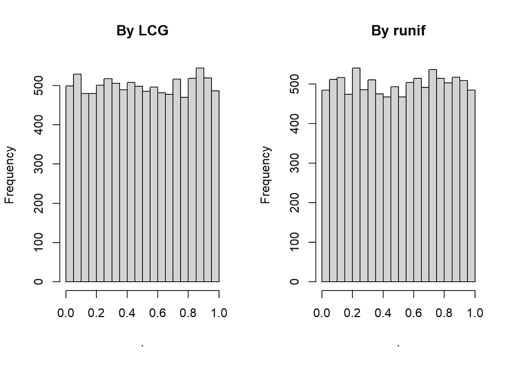

```r
Uni = lcg(a = 7^5,c = 0,m = 2^31-1,run.length = 10000,seed = 5)

par(mfrow=c(1,2))
Uni$U %>% as.numeric() %>% hist(.,main="By LCG")
runif(10000) %>% hist(.,main="By runif")
```

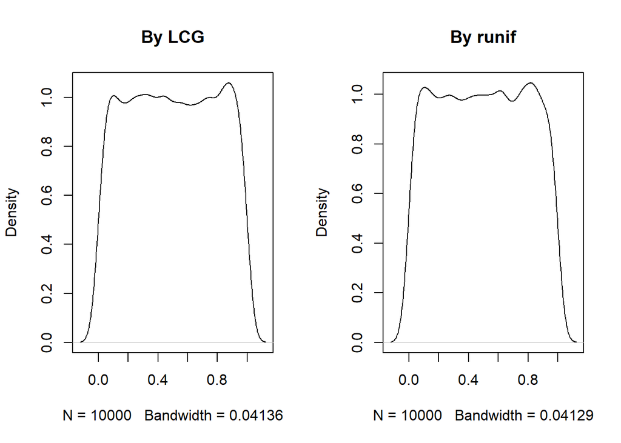

```r
par(mfrow=c(1,2))
plot(density(Uni$U),main="By LCG")
plot(density(runif(10000)),main="By runif")
```

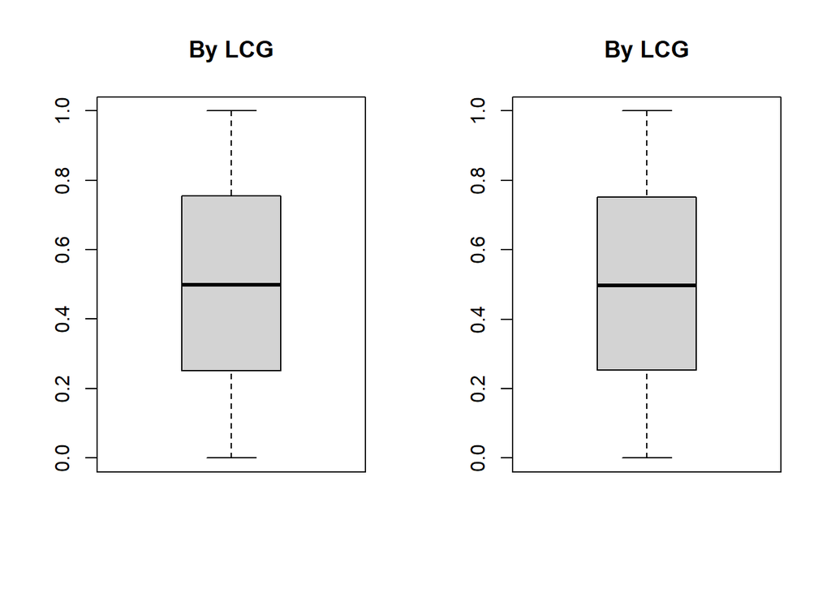

```r
boxplot(Uni$U,main="By LCG");boxplot(runif(10000),main="By LCG")
```

# Problem 1

## (a)

以$Box-Muller$法製造出10000個標準常態  
圖左邊為以LCG製造的$Box-Muller$方法所畫的直方圖及DensityPlot，與右圖$rnorm()$相比起來十分相似。  
從盒狀圖來看，也可看出兩組資料十分相近，僅在Q1,Q3以外，$Box-Muller$法較$rnorm()$些微多一些。

```r
# 此為Box-Muller所用之演算法
fnc = function(U1,U2){
  sqrt(-2*log(U1))*cos(2*pi*U2)
}
```

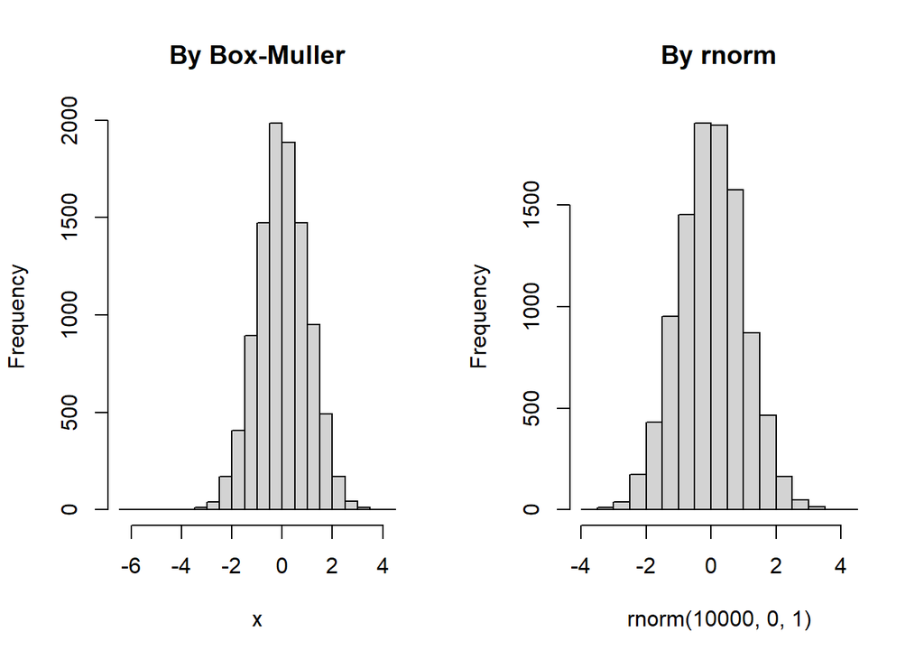

```r
x = fnc(sample(Uni$U,10000),sample(Uni$U,10000))
y = fnc(sample(Uni$U,10000),sample(Uni$U,10000))

par(mfrow=c(1,2))
hist(x,main = "By Box-Muller");hist(rnorm(10000,0,1),main = "By rnorm")
```

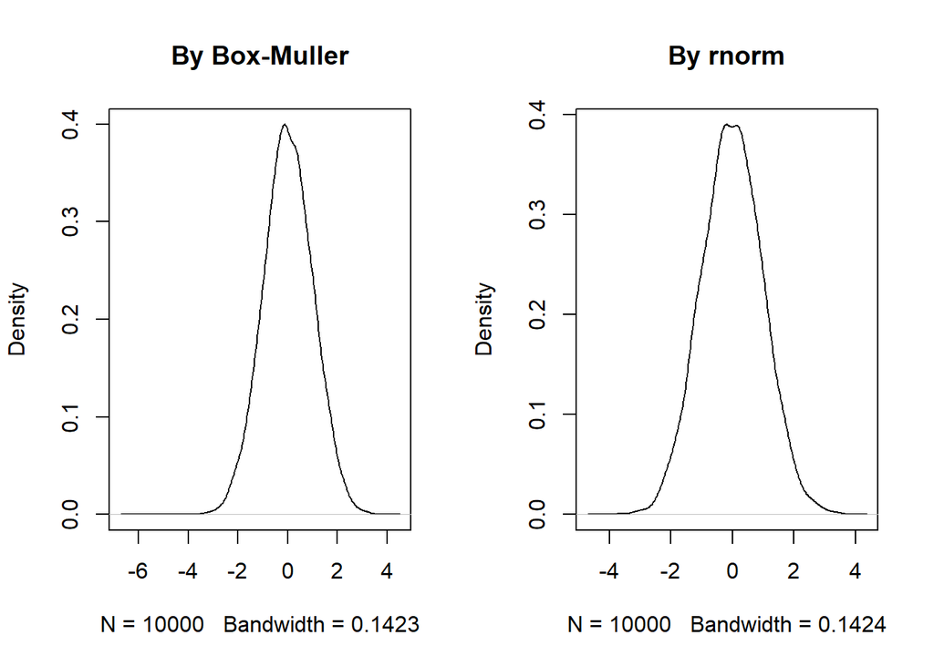

```r
plot(density(x),main="By Box-Muller");plot(density(rnorm(10000,0,1)),main="By rnorm")
```

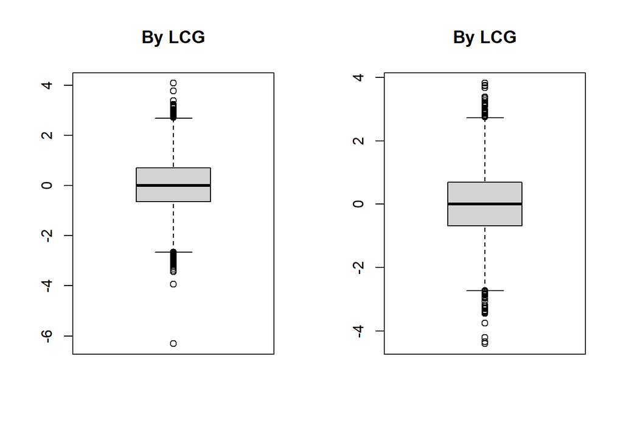

```r
boxplot(x,main="By LCG");boxplot(rnorm(10000,0,1),main="By LCG")
```

## (b)

需要用到指數分配，放在第二題結束的地方

# Problem 2

## (a)

圖左邊為自製以上課所教的演算法所得到$Poisson(10)$的樣本，所畫的直方圖及DensityPlot，與右圖$rpois()$相比起來十分相似。  
從盒狀圖來看，也可看出兩組資料十分相近。

```r
# 此生成Poisson分配所用之演算法

Poisson = function(mu,n){
  X = sapply(1:n, function(a){
    t = 0 ; X = 0 ; lambda = mu
    while (t<1) {
      U = sample(Uni$U,1)
      t = t - (1/lambda)*log(U)
      X = X+1
    }
    X = X-1
    X
  })

  return(X)
}
```

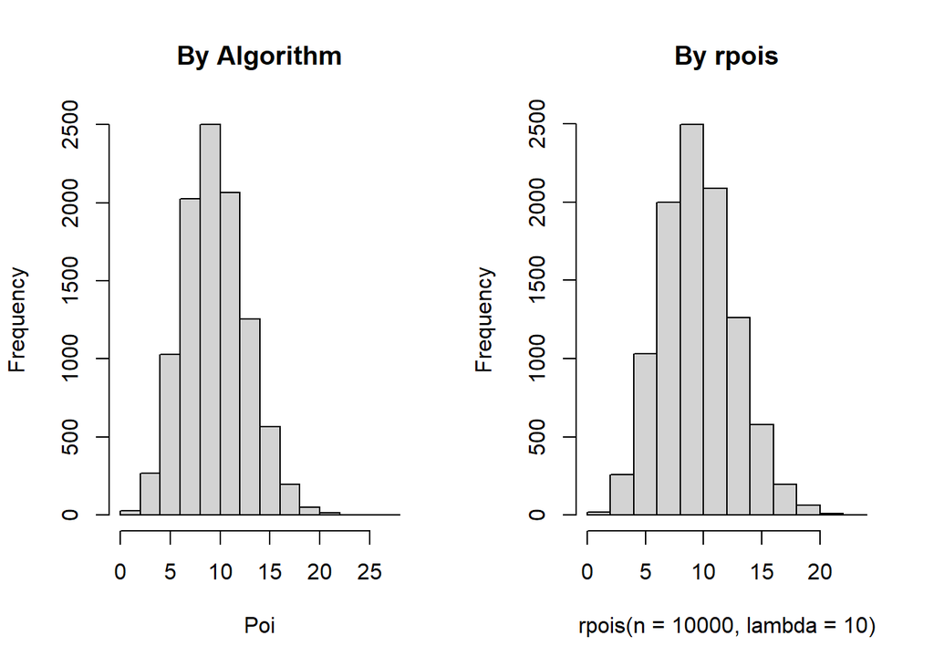

```r
par(mfrow=c(1,2))
Poi = Poisson(10,10000)
hist(Poi,main="By Algorithm");hist(rpois(n = 10000,lambda = 10),main="By rpois")
```

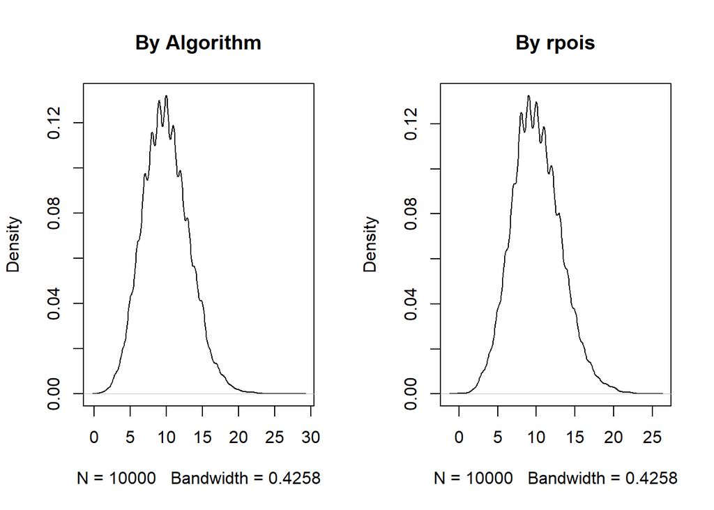

```r
plot(density(Poi),main="By Algorithm");plot(density(rpois(n = 10000,lambda = 10)),main="By rpois")
```

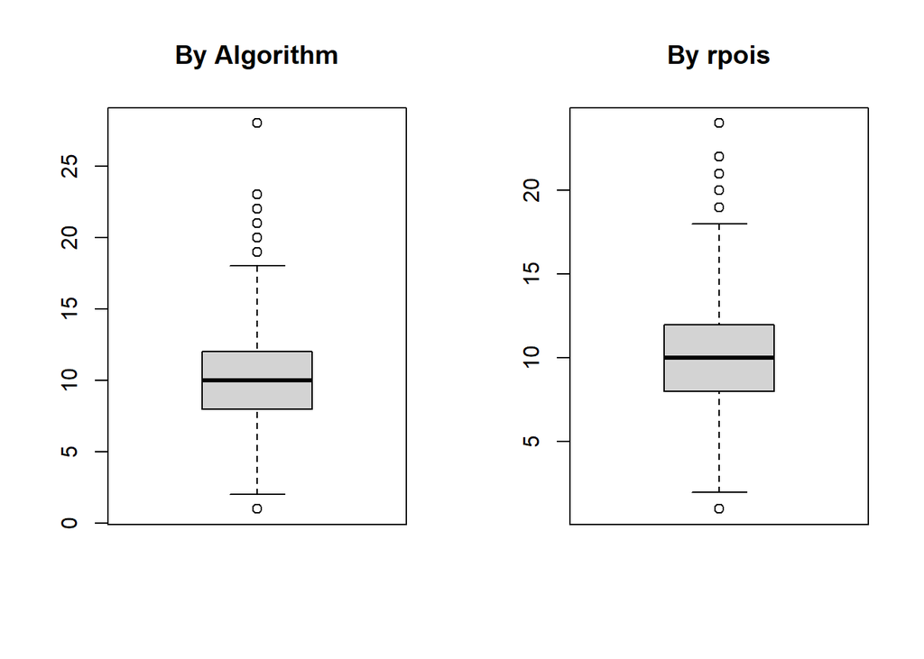

```r
boxplot(Poi,main="By Algorithm");boxplot(rpois(n = 10000,lambda = 10),main="By rpois")
```

## (b)

```r
# 此為生成Exponential分配所用之演算法
EXP = function(mu,n){
  lambda =mu
  N = sapply(1:n, function(a){
    U = sample(Uni$U,1)
    X = -(1/lambda)*log(U)
  })
  N
}
```

```r
# 此為生成Gamma 分配所用之演算法
GAM = function(a,b,n){
  i = 1
  x = matrix(0,nrow = n)
  repeat{
    if(i>a) break
    y = EXP(b,n) %>% as.matrix()
    x = x+y
    i = i+1
  }
  return(x)
}
```

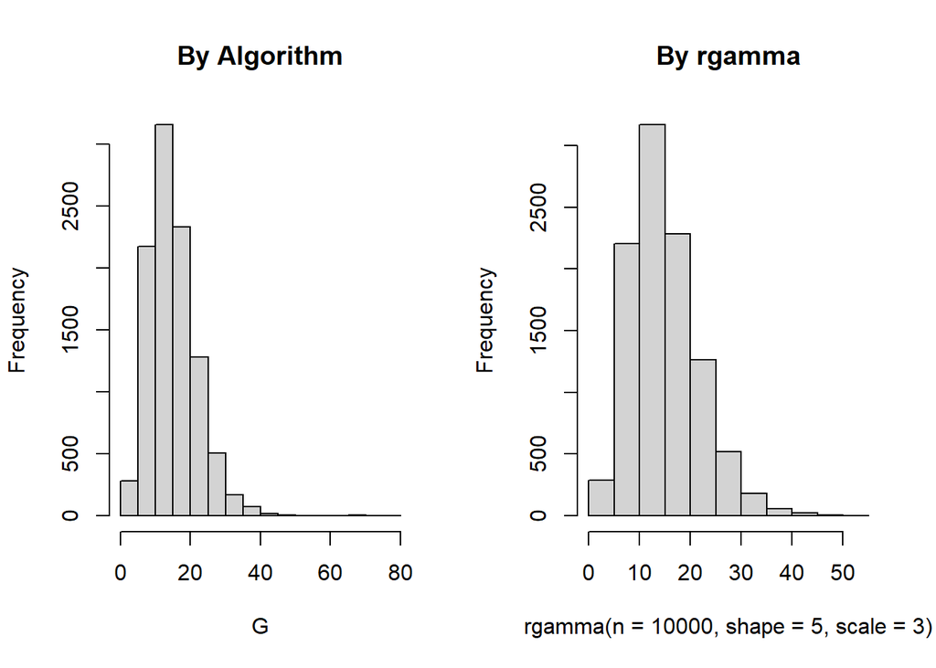

```r
E = EXP(3,10000)
G = GAM(5,1/3,10000)
par(mfrow=c(1,2))
hist(G,main="By Algorithm");hist(rgamma(n=10000,shape = 5,scale = 3),main="By rgamma")
```

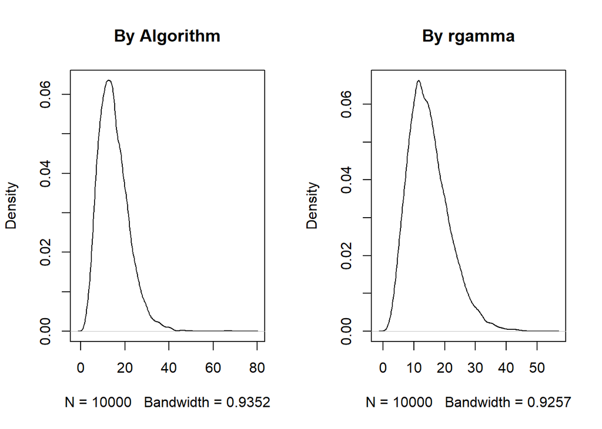

```r
plot(density(G),main="By Algorithm");plot(density(rgamma(n=10000,shape = 5,scale = 3)),main="By rgamma")
```

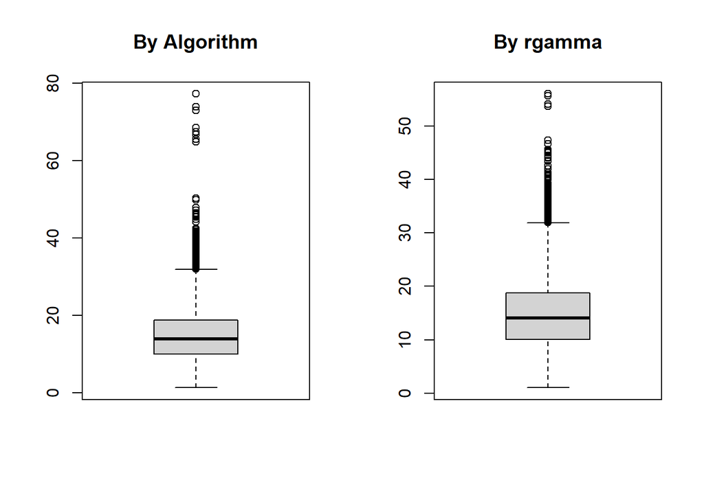

```r
boxplot(G,main="By Algorithm");boxplot(rgamma(n=10000,shape = 5,scale = 3),main="By rgamma")
```

## Problem 1

### (b)

以$Acceptance-Rejection\ Approach$所產生的10000筆樣本。

```r
E = EXP(1,10000)

NormalAR = function(c,n){
  f = function(z){         #設定f為標準常態分配
    sqrt(2/pi)*exp(-z^2/2)
  }
  g = function(z){        #設定g為exp(1)
    exp(-z)
  }

  f_z = as.vector(rep(0,n))
  i = 0   #設定i迭代至所需樣本數
  b = 1
  a = c() #設定a,b紀錄該次是否接受，計算Acceptance Rate
  while (i< n){
    b = b+1
    z = -log(sample(Uni$U,1))
    u1 = sample(Uni$U,1)
    a[b] = ifelse(u1 < f(z)/(c*g(z)),"Y","N")

    if(u1 < f(z)/(c*g(z))){

      u2 = sample(Uni$U,1)
      if(u2 < 0.5) { Z = z } else {Z = -z }
      i = i+1
      f_z[i] = Z
    }
  }
  return(list(f_z,a))
}
```

## Acceptance Rate

```r
vals <- NormalAR(c = 1*sqrt(2/pi)*exp(1/2),n = 10000)
rate = table(vals[[2]])
r = rate[2]/sum(rate)*100
r = round(r,2)
paste0("Acceptance_Rate_1 : ",r,"%")
```

```
## [1] "Acceptance_Rate_1 : 76.08%"
```

```r
vals <- NormalAR(c = 2*sqrt(2/pi)*exp(1/2),n = 10000)
rate = table(vals[[2]])
r = rate[2]/sum(rate)*100
r = round(r,2)

paste0("Acceptance_Rate_2 : ",r,"%")
```

```
## [1] "Acceptance_Rate_2 : 38.28%"
```

先生成$Normal \ Distribution$，圖左所生成樣本畫的直方圖及DensityPlot，與右圖$rnorm()$相比起來十分相似。  
從盒狀圖來看，也可看出兩組資料十分相近。

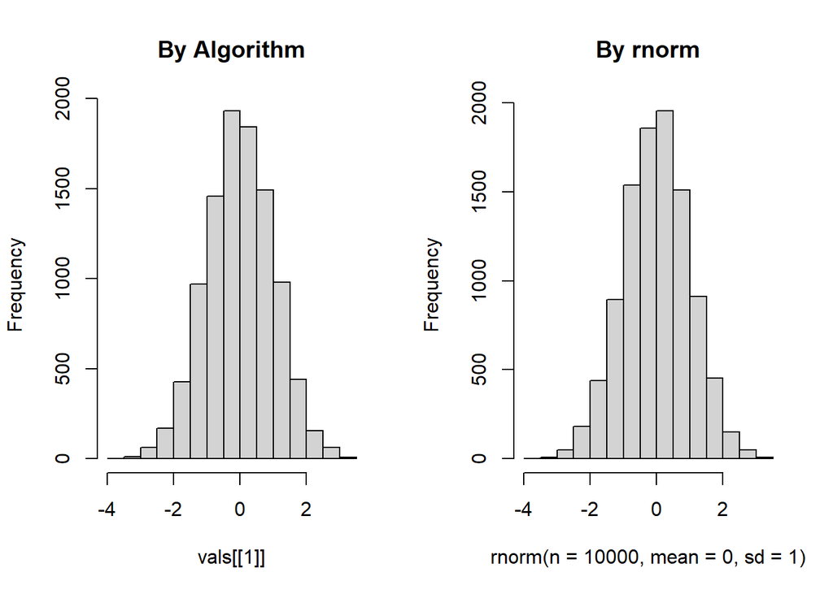

```r
par(mfrow=c(1,2))
vals <- NormalAR(c = sqrt(2/pi)*exp(1/2),n = 10000)
hist(vals[[1]],main="By Algorithm");hist(rnorm(n=10000,mean = 0,sd = 1),main="By rnorm")
```

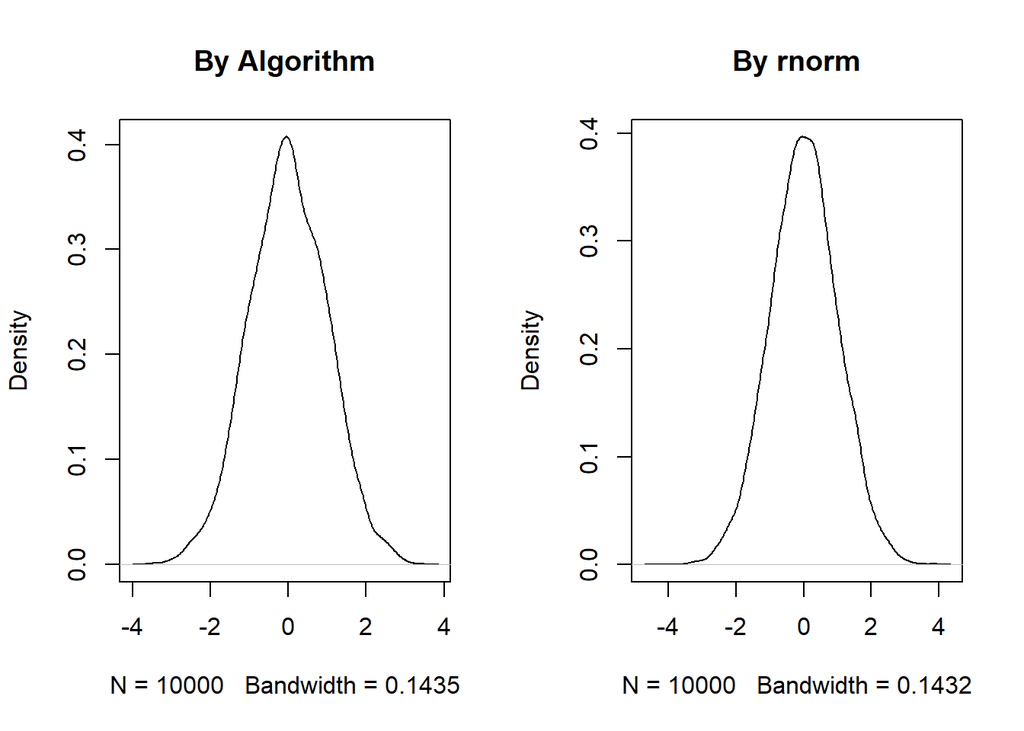

```r
plot(density(vals[[1]]),main="By Algorithm");plot(density(rnorm(n=10000,mean = 0,sd = 1)),main="By rnorm")
```

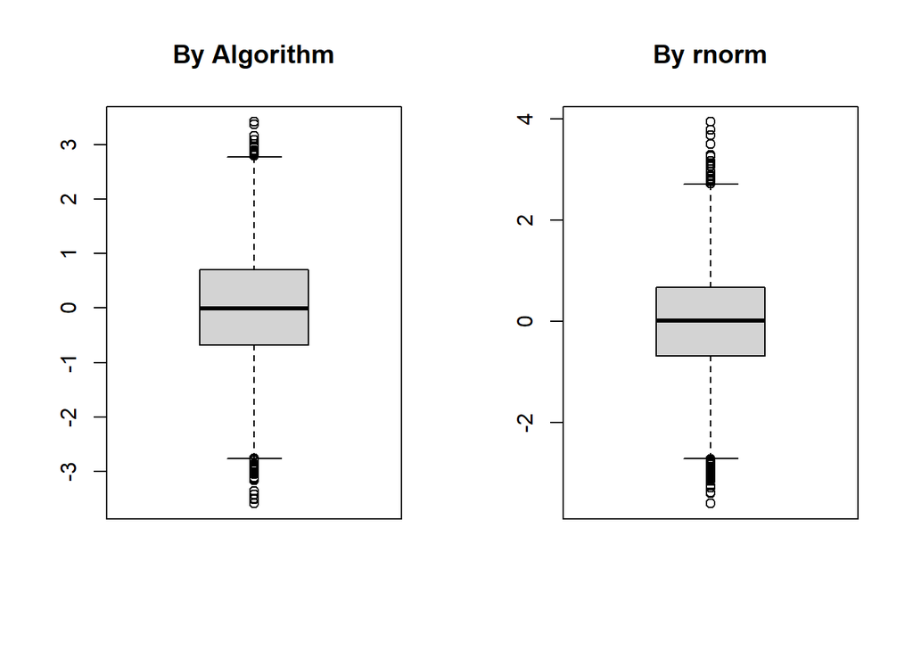

```r
boxplot(vals[[1]],main="By Algorithm");boxplot(rnorm(n=10000,mean = 0,sd = 1),main="By rnorm")
```

# Problem 3

## (c)

```r
# 樣本產生方式，將Gamma生成樣本帶入Poisson分配

G = GAM(a = 5,b = 1/3,n = 10000)
x = matrix(0,nrow=10000)
for (i in 1:10000) {
  x[i,] = Poisson(mu = G[i],n=1)
}
```

由上兩題可得知此混和分配為負二項分配，將生成樣本與$rnbinom()$比較。  
圖左所生成樣本畫的直方圖及DensityPlot，與右圖$rnbinom()$相比起來十分相似。  
從盒狀圖來看，也可看出兩組資料十分相近，但自生成的樣本有偏離較大的值出現。

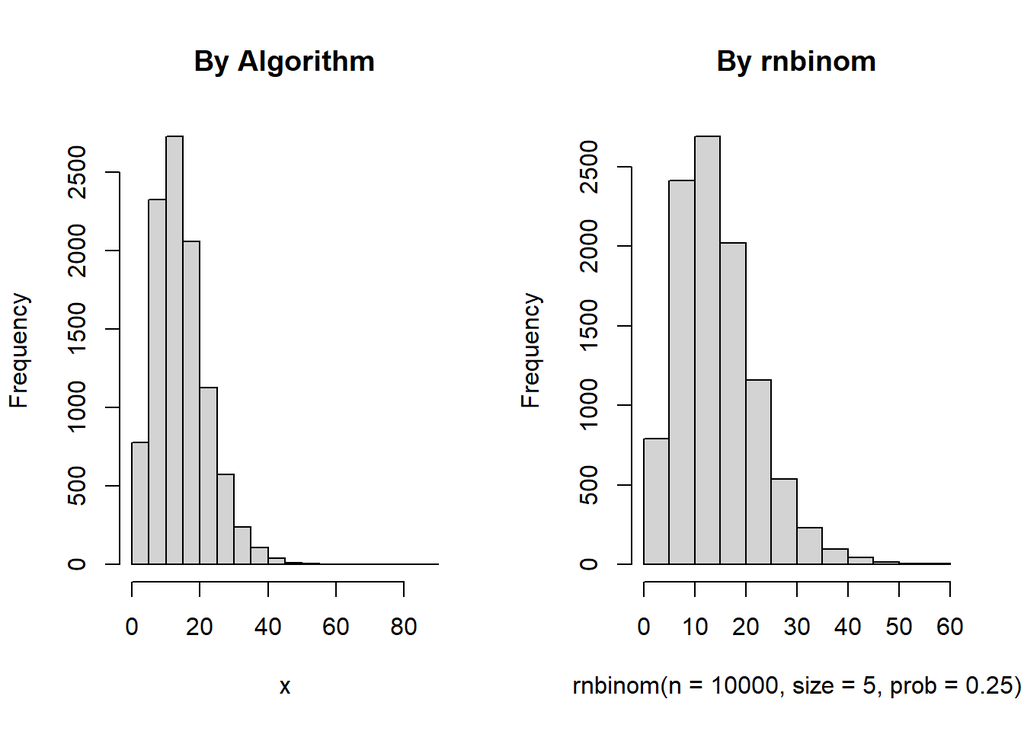

```r
par(mfrow=c(1,2))
hist(x,main="By Algorithm");hist(rnbinom(n =10000,size = 5,prob = 0.25),
                                 main="By rnbinom")
```

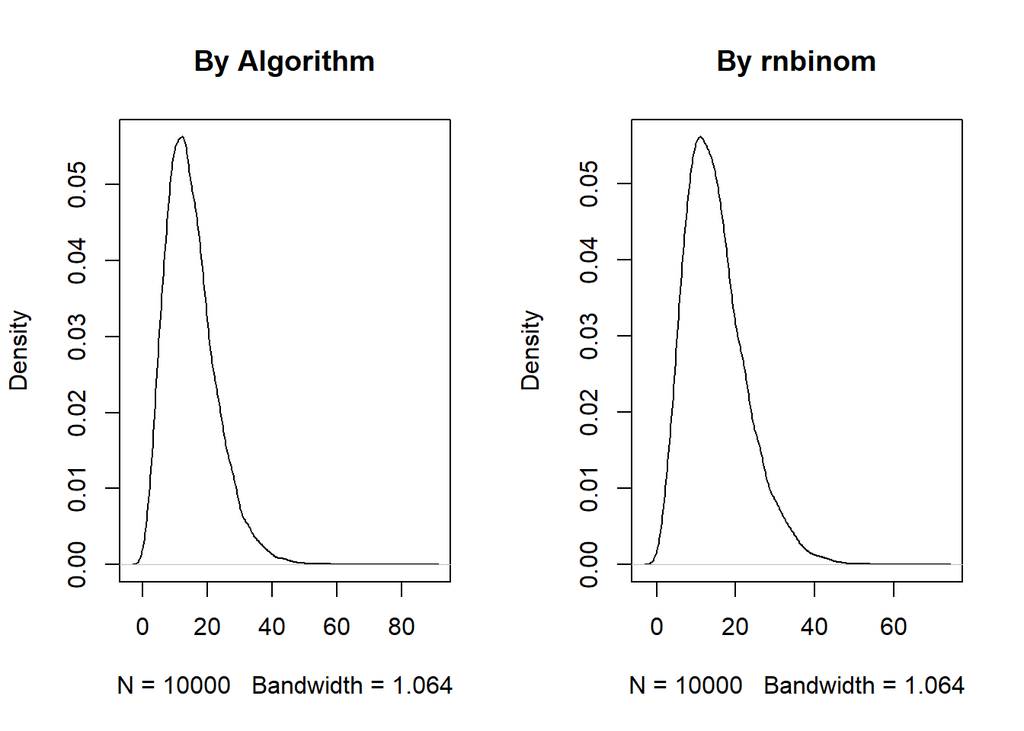

```r
plot(density(x),main="By Algorithm");plot(density(rnbinom(n =10000,size = 5,prob = 0.25)),
                                             main="By rnbinom")
```

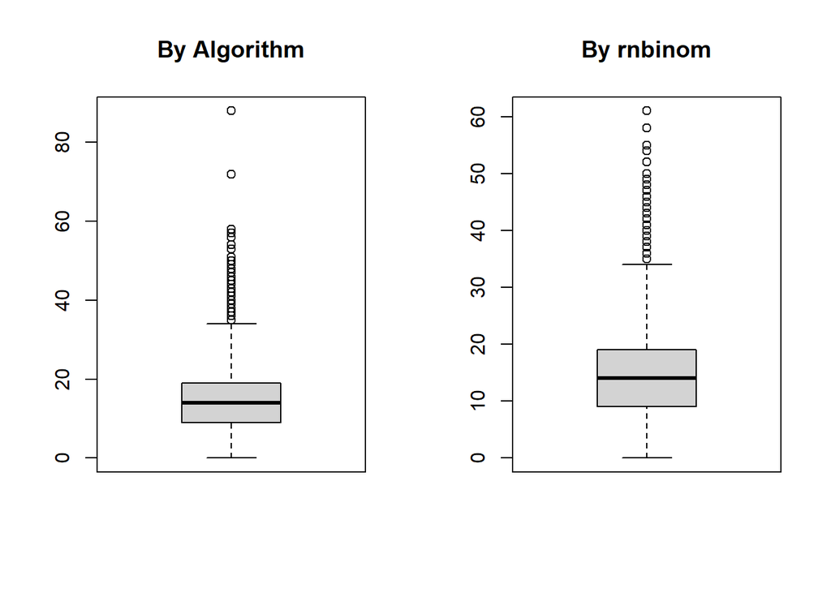

```r
boxplot(x,main="By Algorithm");boxplot(rnbinom(n =10000,size = 5,prob = 0.25),
                                          main="By rnbinom")
```

可發現自生成樣本的平均數約為15，變異數約為60，  
與使用$rnbinom()$所產生的樣本結果相似。

```r
paste0("Mean from the samples by myself: ",mean(x))
```

```
## [1] "Mean from the samples by myself: 15.0301"
```

```r
paste0("Mean from the samples by rnbinom(): ",mean(rnbinom(n =10000,size = 5,prob = 0.25)))
```

```
## [1] "Mean from the samples by rnbinom(): 15.0012"
```

```r
paste0("Variance from the samples by myself: ",var(x))
```

```
## [1] "Variance from the samples by myself: 60.7978737773777"
```

```r
paste0("Variance from the samples by rnbinom(): ",var(rnbinom(n =10000,size = 5,prob = 0.25)))
```

```
## [1] "Variance from the samples by rnbinom(): 61.1769071307131"
```

# Problem 4

## (b)

由(a)小題可得知其機率密度函數，其生成樣本之演算法解釋如下： 1. 自$Uniform(0,1)$抽一項,$X$ 2. 若$X>0.75$，則生成$N(3,1)$，若$X<=0.75$則生成$N(0,1)$

```r
vals <- NormalAR(c = sqrt(2/pi)*exp(1/2),n = 10000)

#The number of samples from the mixture distribution
N = 10000
#Sample N random uniforms U
U =runif(N)
#Variable to store the samples from the mixture distribution
rand.samples = rep(NA,N)
#Sampling from the mixture
for(i in 1:N){
  if(U[i]<0.75){
    rand.samples[i] = sample(vals[[1]],1)
  }else{
    rand.samples[i] = sample(vals[[1]],1)+3 #自N(0,1)平移3，變成N(3,1)
  }
}
```

生成樣本後，畫出該分配的直方圖及DensityPlot，可發現在$X$在0,3的地方有雙峰的現象，符合我們一開始的想像。

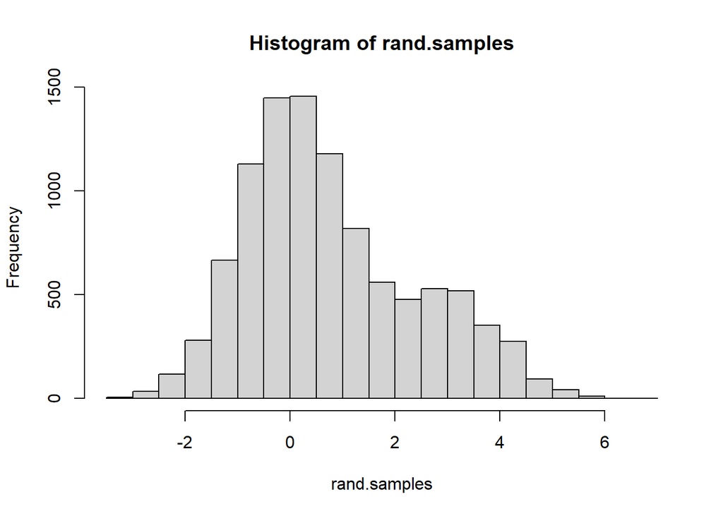

```r
hist(rand.samples)
```

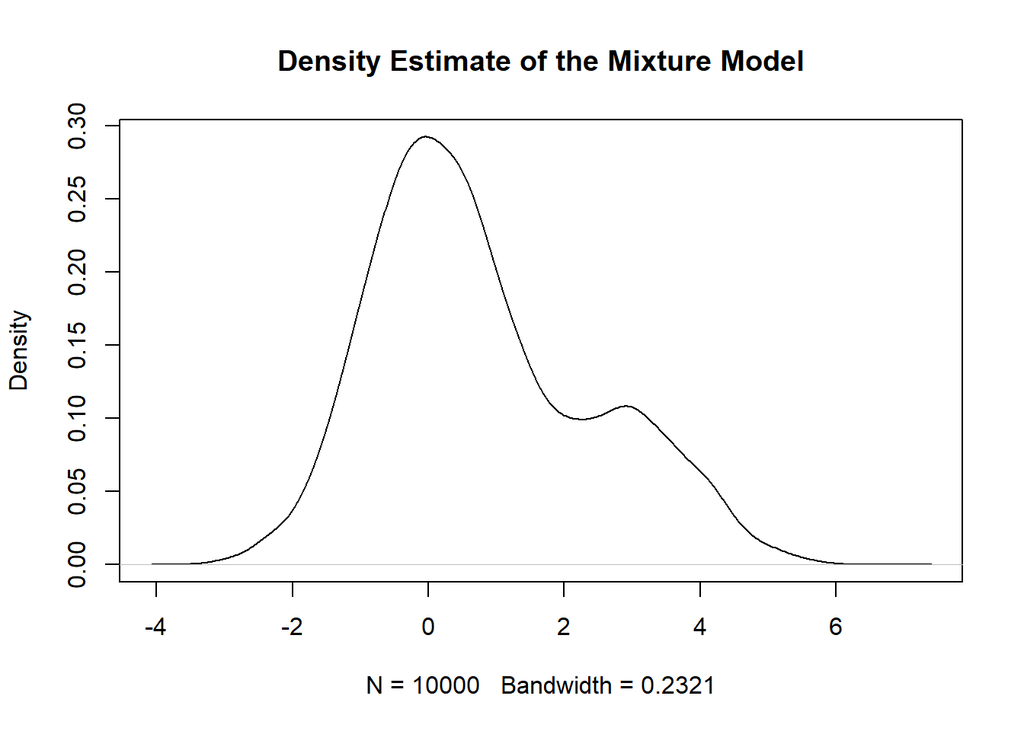

```r
plot(density(rand.samples),main="Density Estimate of the Mixture Model")
```